# DEM 7283 - Splines and Generalized Additive Models

Corey Sparks, PhD

11 April, 2022

In this example, we will describe how to use splines to model nonlinearities in predictor variables and the *generalized additive model*.

## Splines

Splines are nothing more than a set of linear or non-linear functions that are tied together to construct a model for data.

### Piece-wise splines

In the simplest example, consider a regression function whose form changes at some point in the data. So if we see data like this:

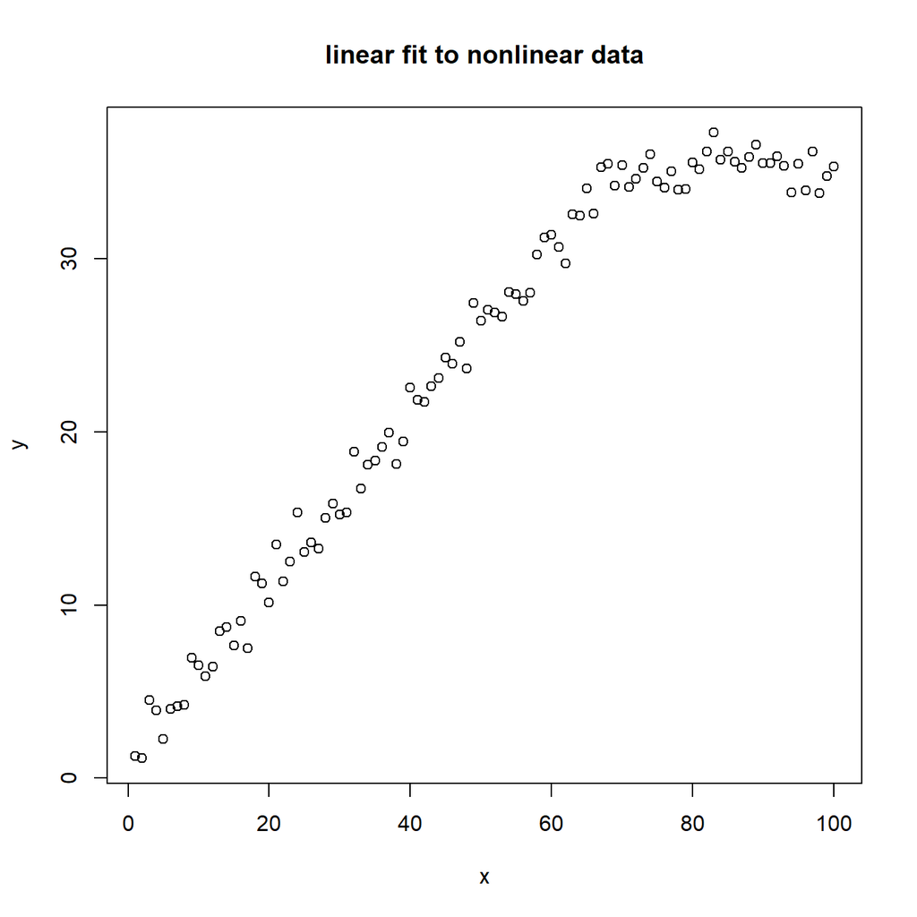

```r
b0<-1; b1=.5;b2=35
x<-seq(1:100)
y1<-rnorm(70,b0+b1*x[1:70], 1)
y2<-rnorm(30, b2, 1)

y<-c(y1, y2)
plot(y~x, main="linear fit to nonlinear data")
```

we might say, yes, I can fit a linear model to that:

```r
plot(y~x, main="linear fit to nonlinear data")
lin<-lm(y~x)
summary(lin)
```

```
##
## Call:
## lm(formula = y ~ x)
##
## Residuals:
##     Min      1Q  Median      3Q     Max
## -7.8098 -1.8653  0.1851  2.2715  5.4057
##
## Coefficients:
##             Estimate Std. Error t value Pr(>|t|)
## (Intercept)  4.58526    0.60831   7.538 2.43e-11 ***
## x            0.37771    0.01046  36.117  < 2e-16 ***
## ---
## Signif. codes:  0 '***' 0.001 '**' 0.01 '*' 0.05 '.' 0.1 ' ' 1
##
## Residual standard error: 3.019 on 98 degrees of freedom
## Multiple R-squared:  0.9301, Adjusted R-squared:  0.9294
## F-statistic:  1304 on 1 and 98 DF,  p-value: < 2.2e-16
```

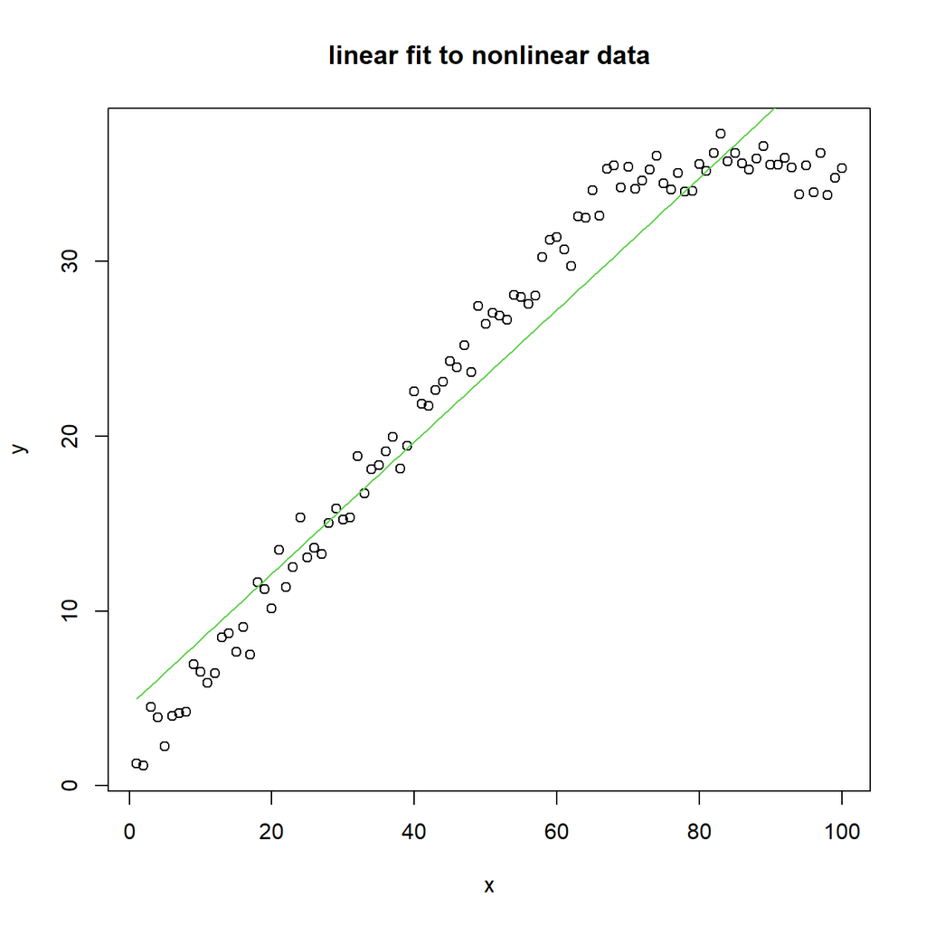

```r
lines(fitted(lin)~x,col=3)
```

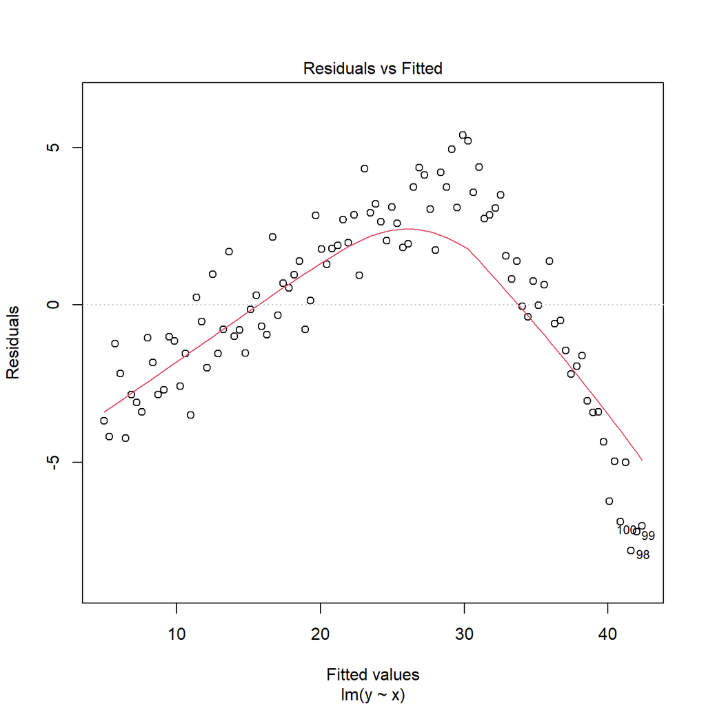

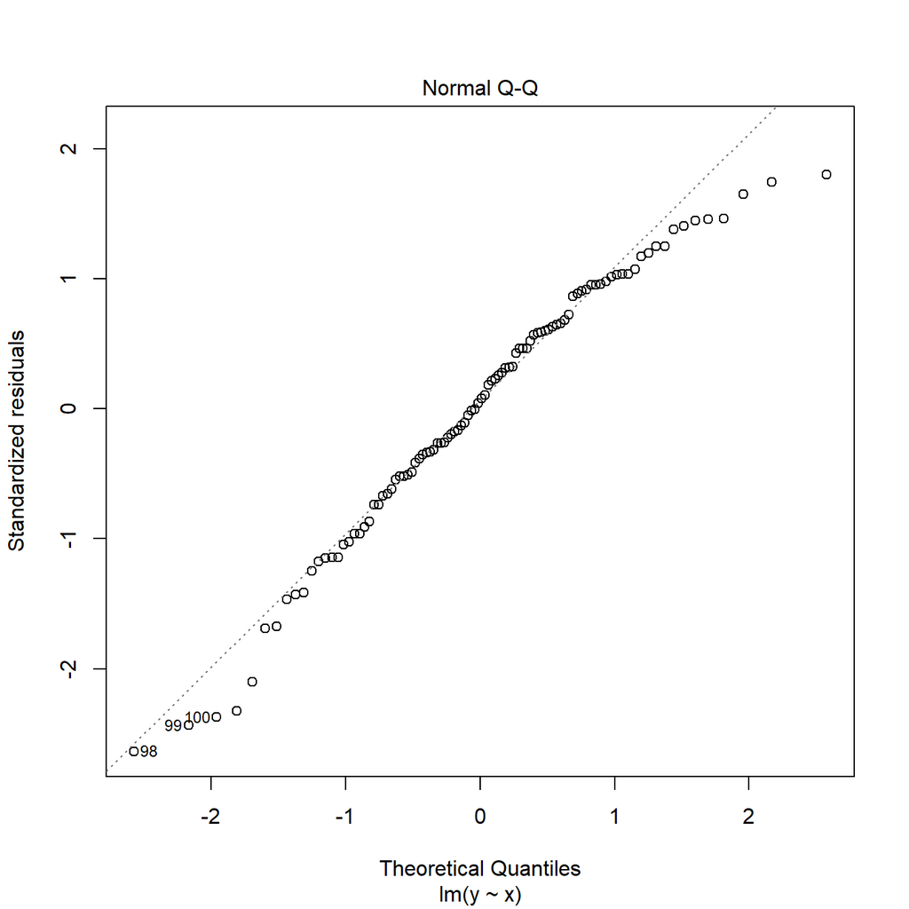

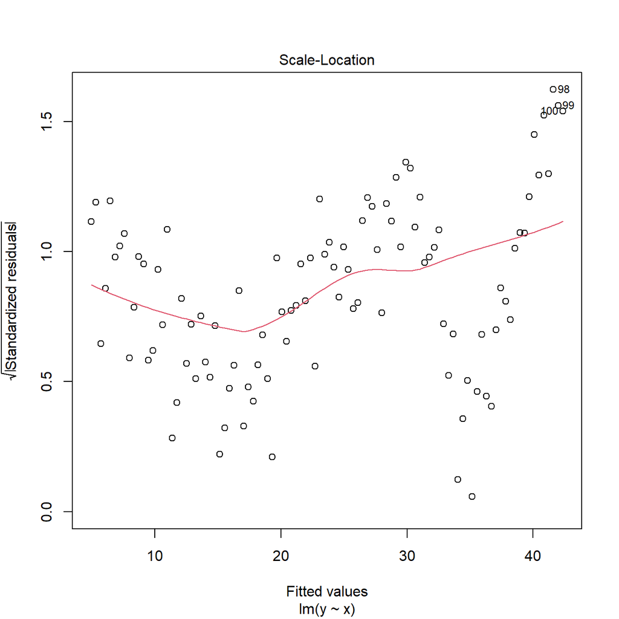

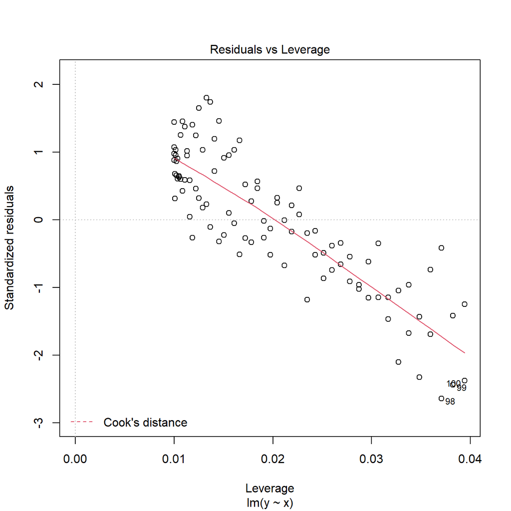

```r
plot(lin)
```

but we would be sorely mistaken, as this model clearly doesn’t fit the data.

Instead, we can model the change in the underlying model structure by using a series of *knots* in the function, or points along the data in which the form of the function changes.

Mathematically, knots can be written as:

Where each of the $F_k (x)$ functions imply a different form in the interval between $x\in [x_{k-1}, x_k]$, where the $k$ breaks are at a given knot in the data.

This would generate a model that looks like this:

```r
sp<-(lm(y~x*I(x<71)+x*I(x>71)))
summary(sp)
```

```
##
## Call:
## lm(formula = y ~ x * I(x < 71) + x * I(x > 71))
##
## Residuals:
##      Min       1Q   Median       3Q      Max
## -2.08036 -0.73727  0.02174  0.63603  2.31558
##
## Coefficients: (1 not defined because of singularities)
##                   Estimate Std. Error t value Pr(>|t|)
## (Intercept)      33.989175   1.828679  18.587   <2e-16 ***
## x                 0.002201   0.021747   0.101     0.92
## I(x < 71)TRUE   -32.791936   1.843941 -17.784   <2e-16 ***
## I(x > 71)TRUE     1.093766   1.048597   1.043     0.30
## x:I(x < 71)TRUE   0.490793   0.022506  21.807   <2e-16 ***
## x:I(x > 71)TRUE         NA         NA      NA       NA
## ---
## Signif. codes:  0 '***' 0.001 '**' 0.01 '*' 0.05 '.' 0.1 ' ' 1
##
## Residual standard error: 0.9798 on 95 degrees of freedom
## Multiple R-squared:  0.9929, Adjusted R-squared:  0.9926
## F-statistic:  3304 on 4 and 95 DF,  p-value: < 2.2e-16
```

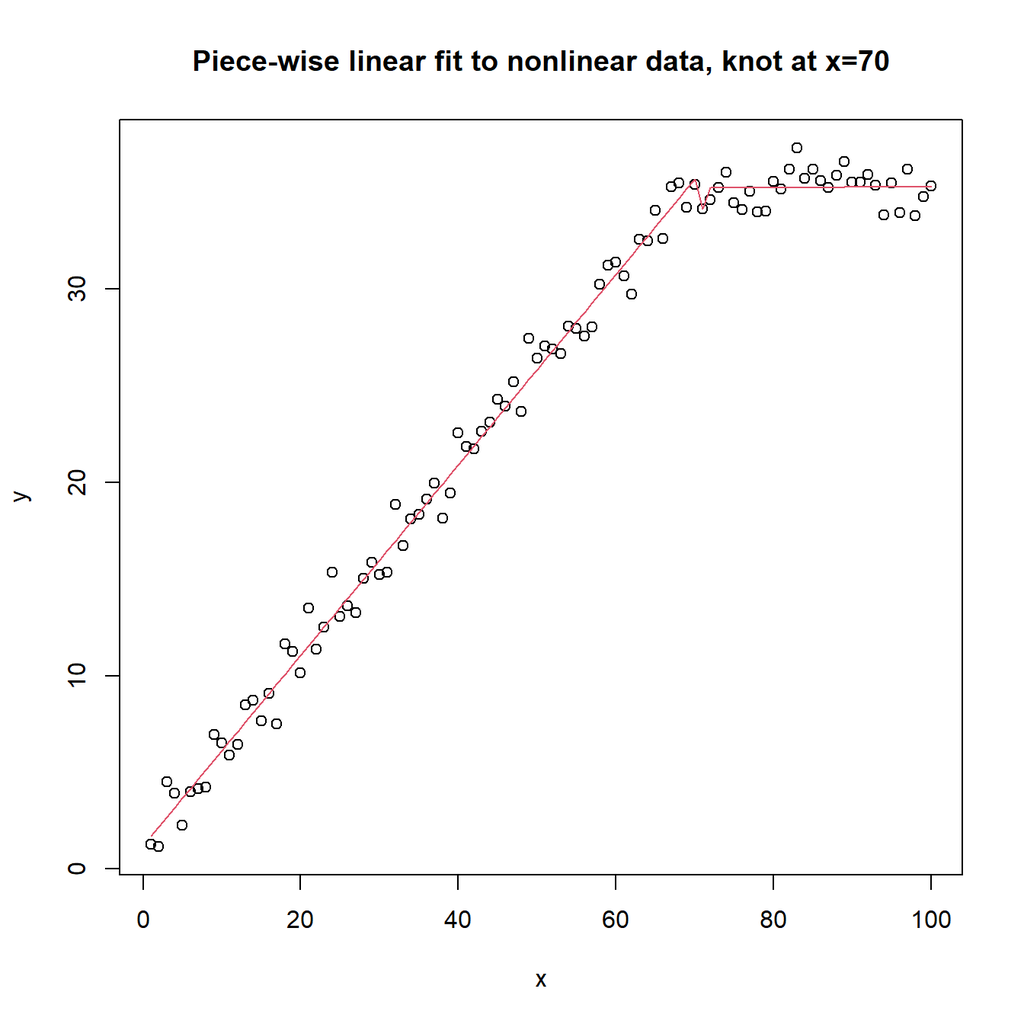

```r
plot(y~x,main="Piece-wise linear fit to nonlinear data, knot at x=70")
lines(fitted(sp)~x,col=2)
```

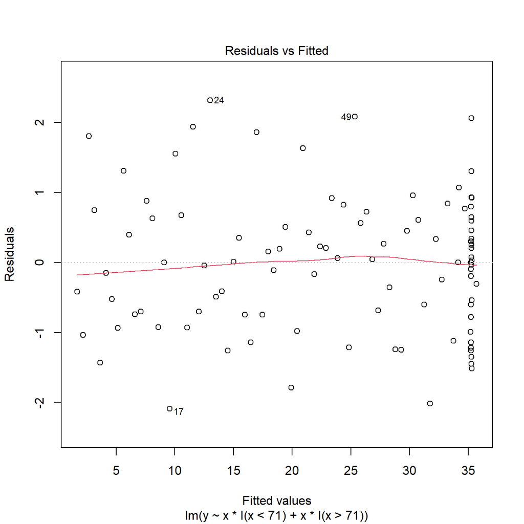

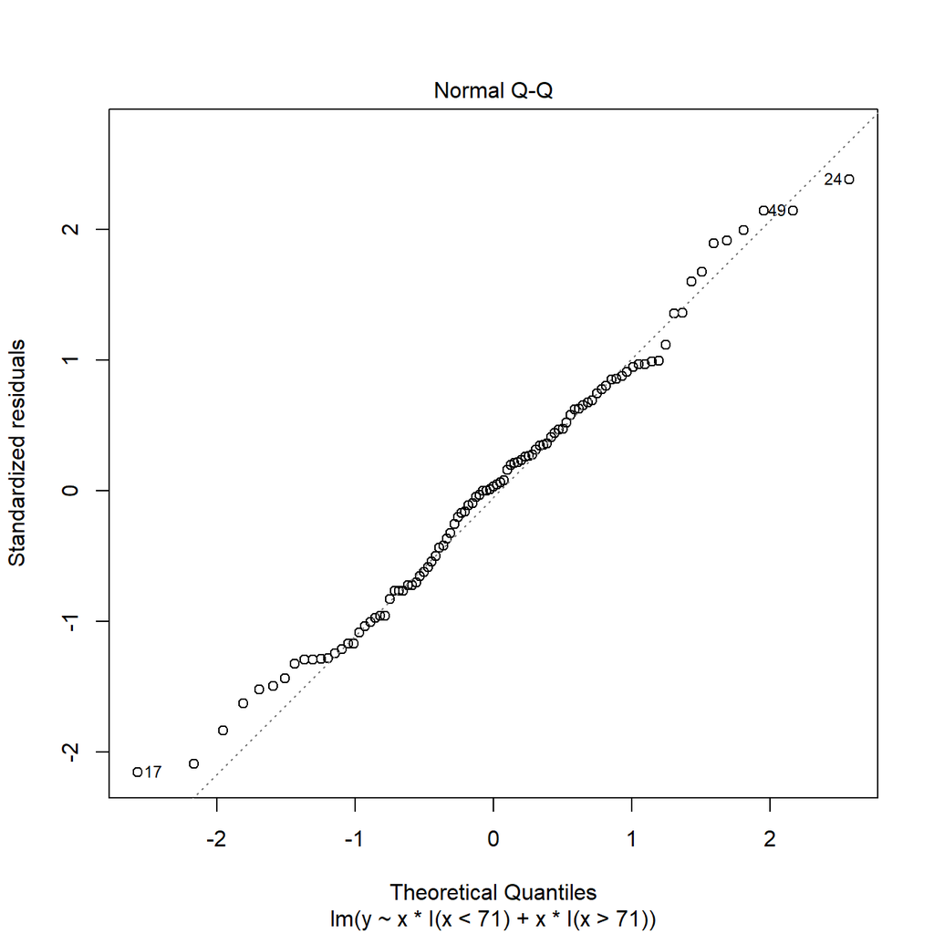

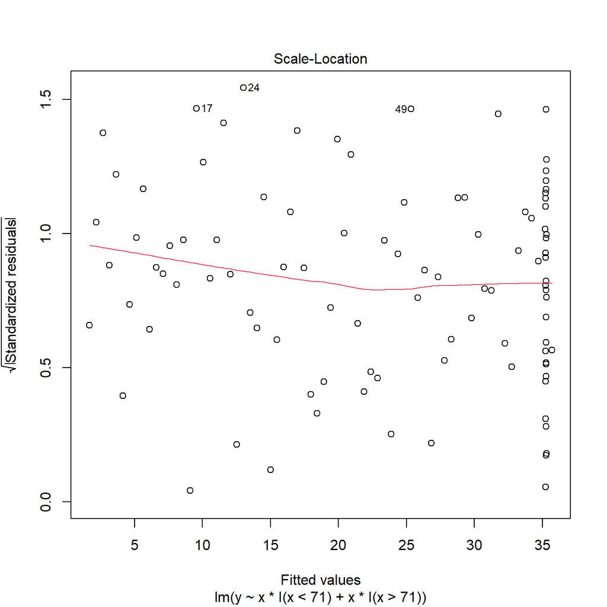

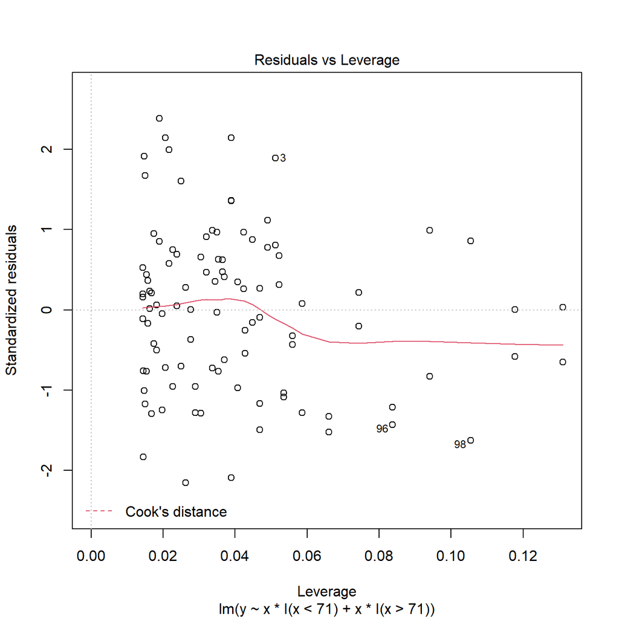

```r
plot(sp)
```

Of course, this can be much more complicated, with multiple knots in the data, to model multiple changes in the underlying data generating function

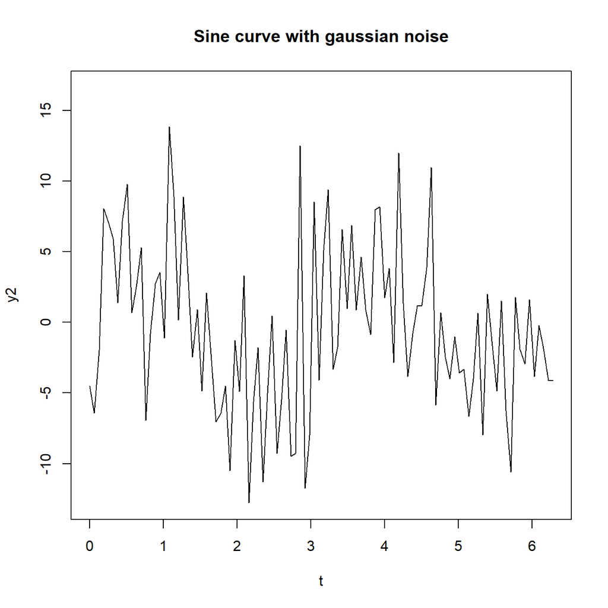

```r
n <- 100 # number of data points
t <-  seq(from=0, to = 2*pi, length.out=100)
a <- 3
b <- 2
c.norm <- rnorm(n, 0, 5)
amp <- 1

# generate data and calculate "y"
set.seed(1)
y2 <- a*sin(b*t)+c.norm*amp # Gaussian/normal error

# plot results
plot(t, y2, t="l", ylim=range(y2)*c(1,1.2), main="Sine curve with gaussian noise")
```

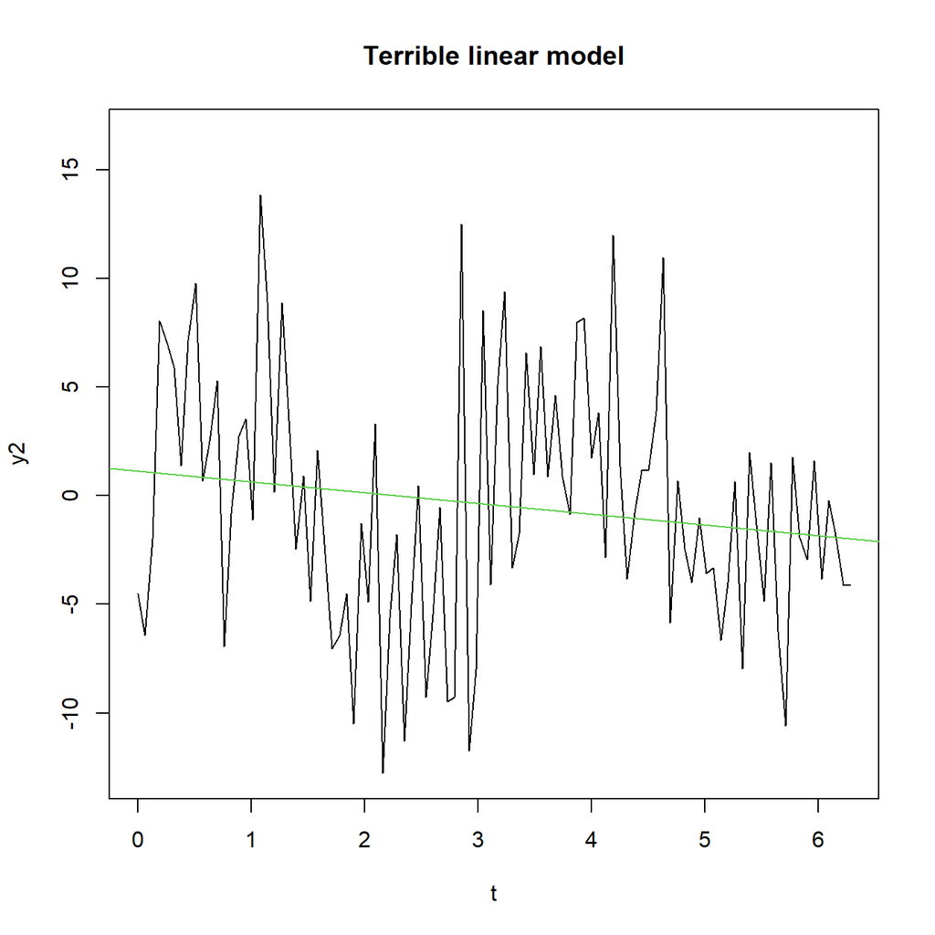

```r
plot(t, y2, t="l", ylim=range(y2)*c(1,1.2), main="Terrible linear model")

abline(lm(y2~t), col=3)
```

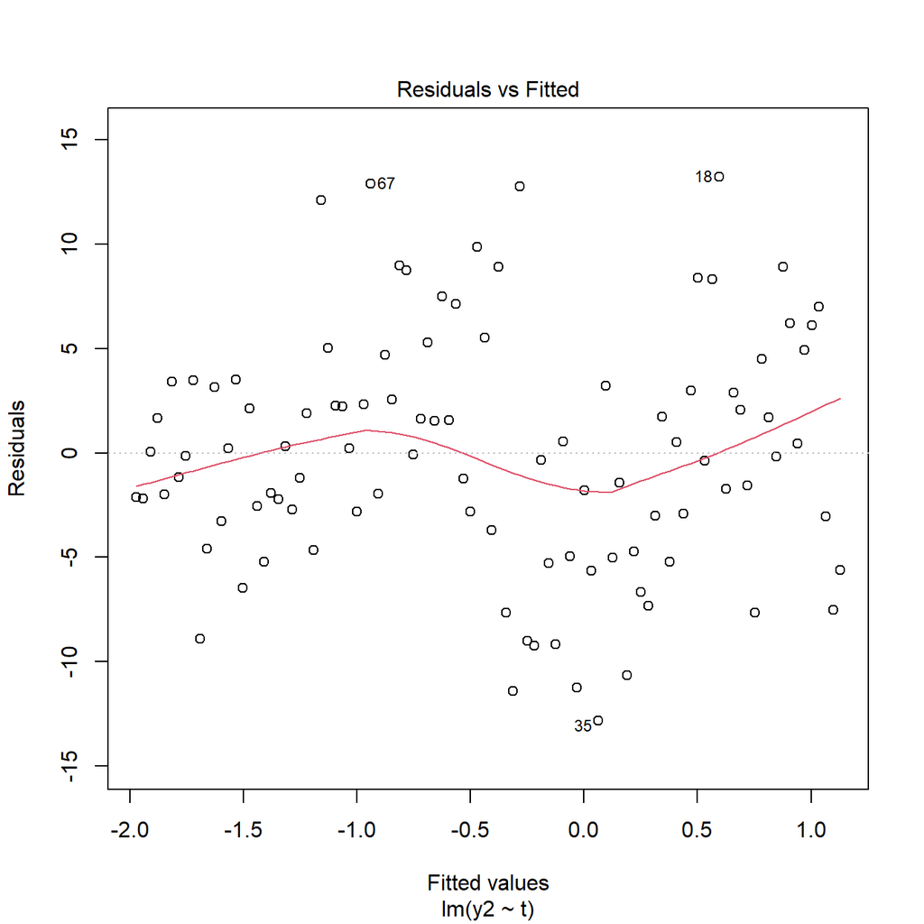

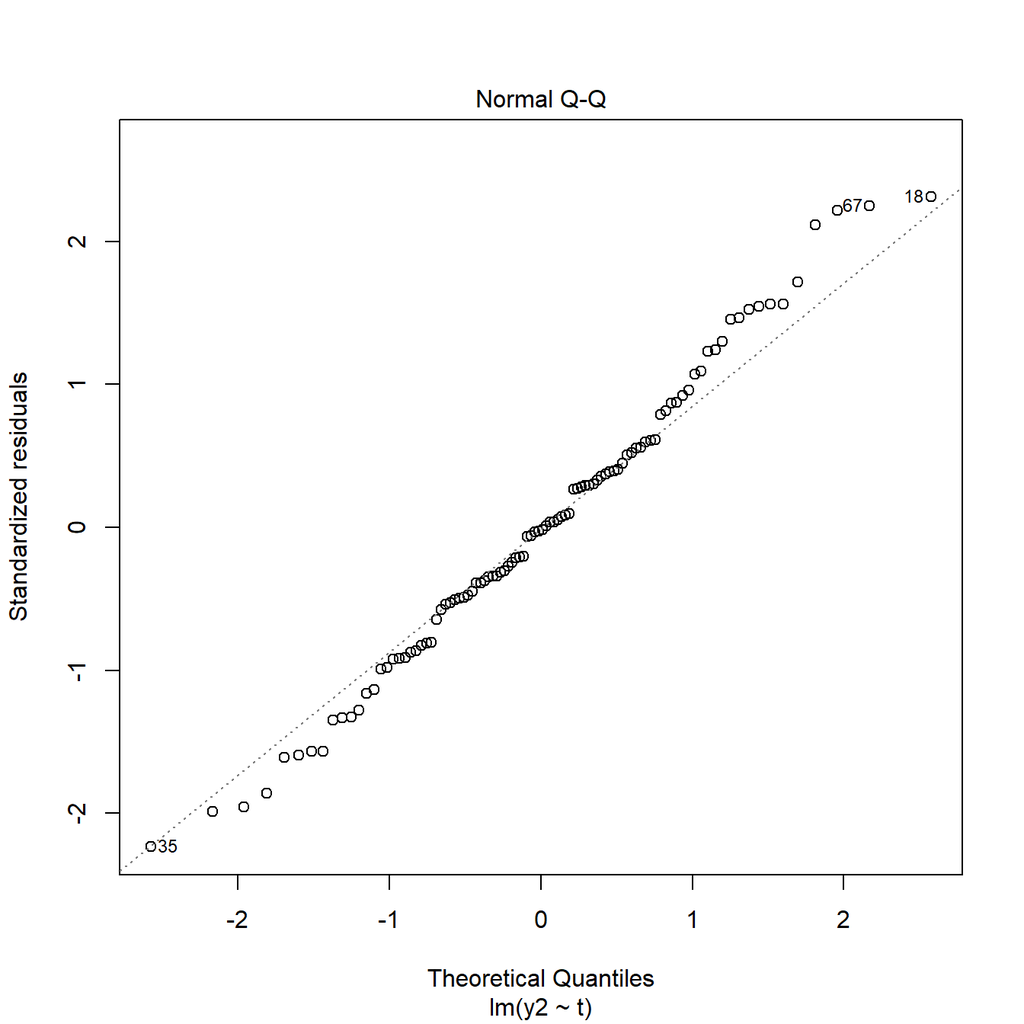

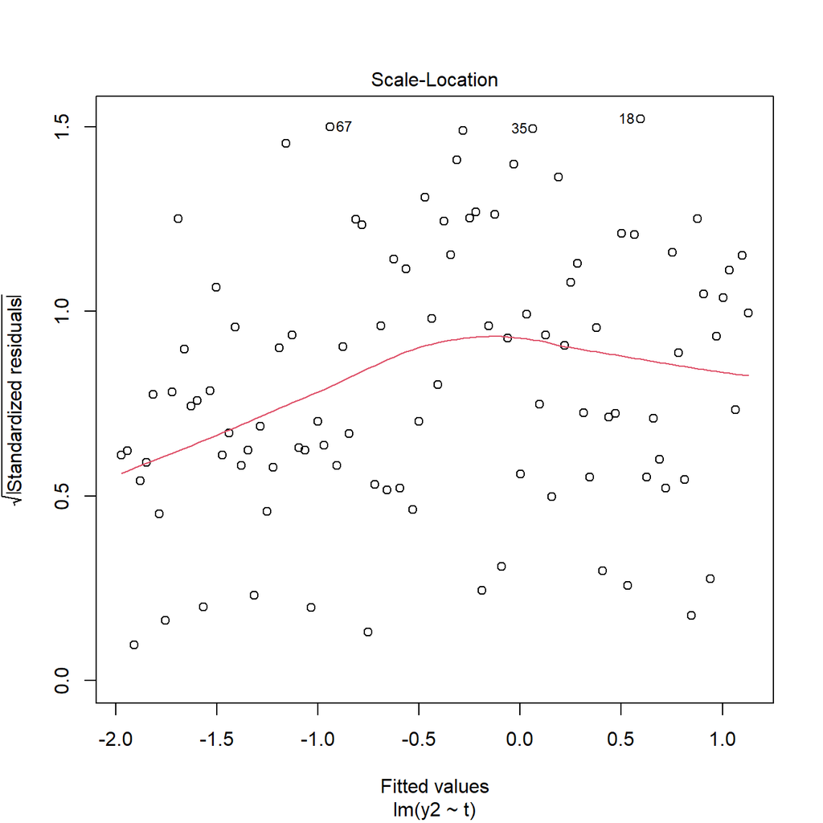

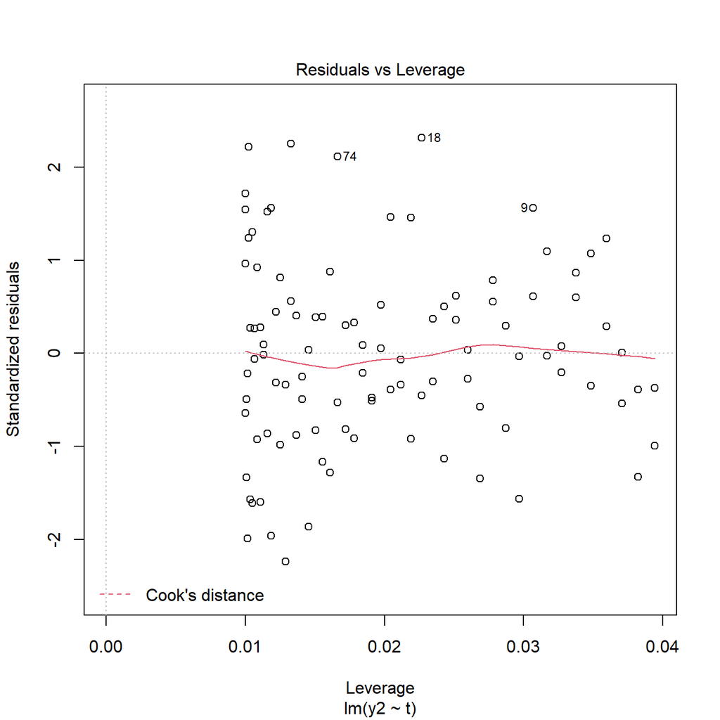

```r
plot(lm(y2~t))
```

Splines are often characterized by the number of knots used to build them

```r
library(splines)
library(mgcv)
```

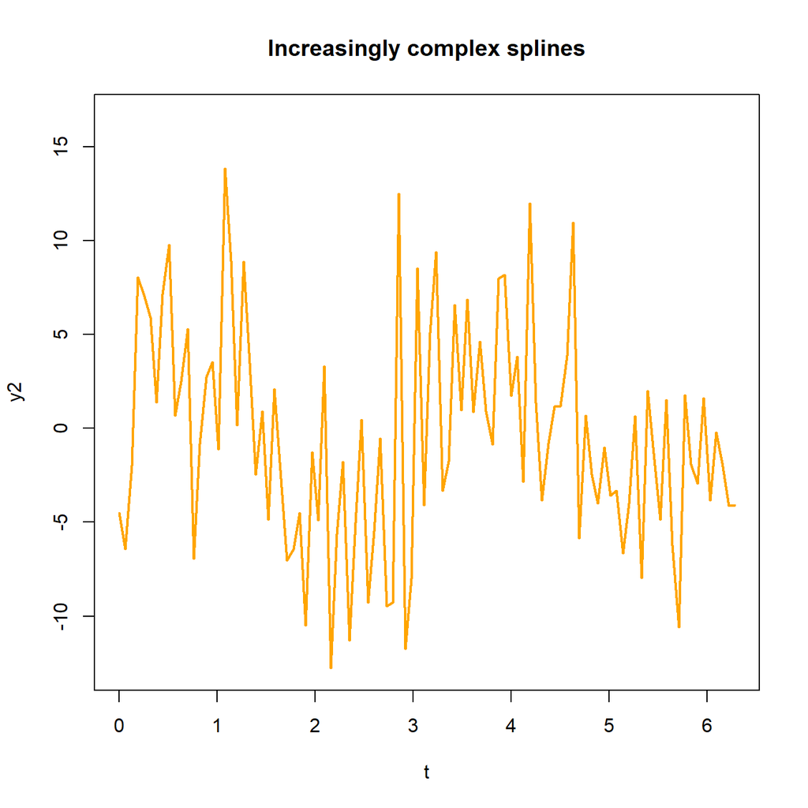

```r
plot(t, y2, t="l", ylim=range(y2)*c(1,1.2), main="Increasingly complex splines")
fit<-spline(y2,t)
#lines(spline(t,y2, n = 4),col="darkgreen",lwd=2,type="l")
#lines(spline(t,y2, n = 10),col="red",lwd=2,type="l")
#lines(spline(t,y2, n = 20),col="blue",lwd=2,type="l")
lines(spline(t,y2, n = 100),col="orange",lwd=2,type="l")
```

## Cubic splines

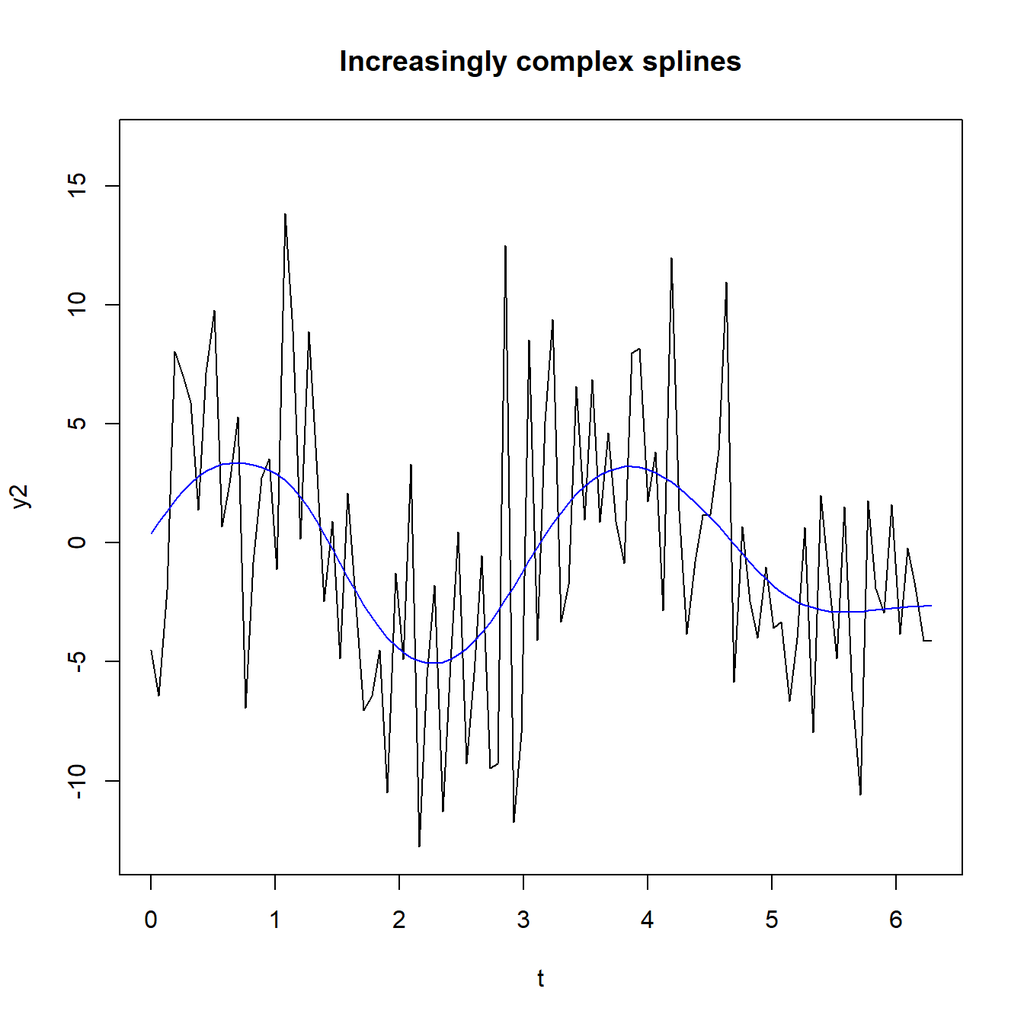

```r
plot(t, y2, t="l", ylim=range(y2)*c(1,1.2), main="Increasingly complex splines")

#fit<-smooth.spline(t, y2, df=2)
#fit5<-smooth.spline(t, y2, df=5)
fit10<-smooth.spline(t, y2)
#lines(fit, col="red")
#lines(fit5, col="green")
lines(fit10, col="blue")
```

## Regression splines

The *generalized additive model* (GAM) is a modeling framework that forms a linear predictor for a regression function through the combination of both smooth and linear terms.

The GAM model forms the linear predctor of a GLM as:

$$E(y)= \beta_0 + f(x_1) + \beta_1
x_2$$

where the $f(x_1)$ term is a regression spline of one of the variables. The models can be a mixture of linear and smooth terms.

```r
library(mgcv) #one library for GAMs
library(ggplot2)
library(dplyr)
dat<-data.frame(y = y2, x = t)

gamfit<-gam(y ~ s(x), data=dat)
summary(gamfit)
```

```
##
## Family: gaussian
## Link function: identity
##
## Formula:
## y ~ s(x)
##
## Parametric coefficients:
##             Estimate Std. Error t value Pr(>|t|)
## (Intercept)  -0.4221     0.5034  -0.839    0.404
##
## Approximate significance of smooth terms:
##       edf Ref.df     F  p-value
## s(x) 6.18  7.338 4.747 0.000114 ***
## ---
## Signif. codes:  0 '***' 0.001 '**' 0.01 '*' 0.05 '.' 0.1 ' ' 1
##
## R-sq.(adj) =  0.253   Deviance explained =   30%
## GCV = 27.301  Scale est. = 25.34     n = 100
```

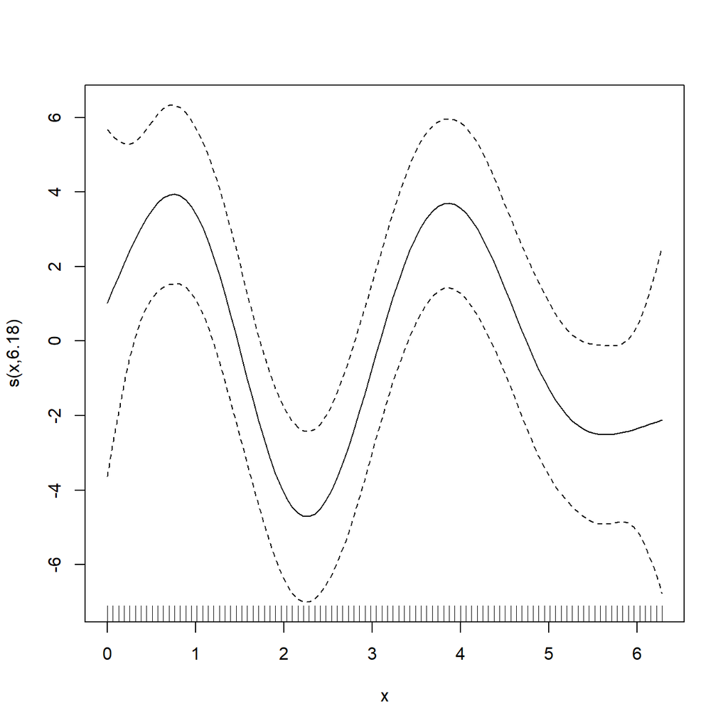

```r
plot(gamfit)
```

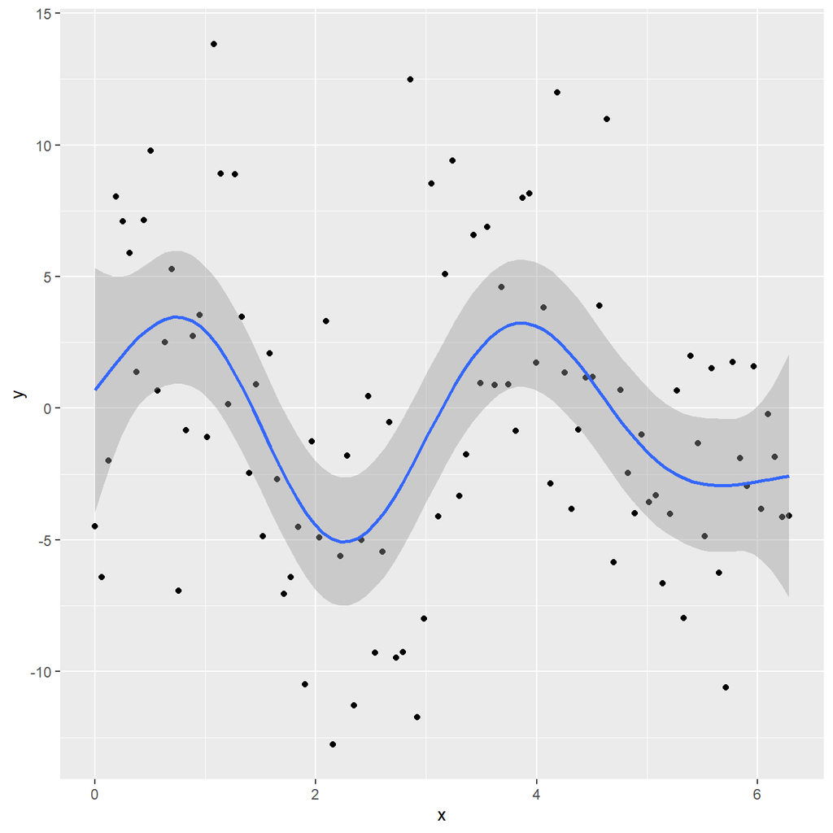

```r
dat%>%
  ggplot(aes(x=x, y=y))+
  geom_point()+
  geom_smooth(method = "gam", formula = y ~ s(x))
```

### BRFSS DATA

```r
load(url("https://github.com/coreysparks/data/blob/master/brfss_2017.Rdata?raw=true"))

set.seed(1234)
#samps<-sample(1:nrow(brfss_17), size = 40000, replace=F)
#brfss_17<-brfss_17[samps,]
```

### Recode variables

```r
library(car)
library(dplyr)

#nice MSA name
brfss_17$mmsa_name<-substr(brfss_17$mmsaname, 1,nchar(brfss_17$mmsaname)-31)

#sex
brfss_17$male<-ifelse(brfss_17$sex==1, 1, 0)

#BMI
brfss_17$bmi<-ifelse(is.na(brfss_17$bmi5)==T, NA, brfss_17$bmi5/100)

#Healthy days
brfss_17$healthdays<-Recode(brfss_17$physhlth, recodes = "88=0; 77=NA; 99=NA")

#Healthy mental health days
brfss_17$healthmdays<-Recode(brfss_17$menthlth, recodes = "88=0; 77=NA; 99=NA")

brfss_17$badhealth<-Recode(brfss_17$genhlth, recodes="4:5=1; 1:3=0; else=NA")
#race/ethnicity
brfss_17$black<-Recode(brfss_17$racegr3, recodes="2=1; 9=NA; else=0")
brfss_17$white<-Recode(brfss_17$racegr3, recodes="1=1; 9=NA; else=0")
brfss_17$other<-Recode(brfss_17$racegr3, recodes="3:4=1; 9=NA; else=0")
brfss_17$hispanic<-Recode(brfss_17$racegr3, recodes="5=1; 9=NA; else=0")

brfss_17$race_eth<-Recode(brfss_17$racegr3,
recodes="1='nhwhite'; 2='nh black'; 3='nh other';4='nh multirace'; 5='hispanic'; else=NA",
as.factor = T)
brfss_17$race_eth<-relevel(brfss_17$race_eth, ref = "nhwhite")

#insurance
brfss_17$ins<-Recode(brfss_17$hlthpln1, recodes ="7:9=NA; 1=1;2=0")

#income grouping
brfss_17$inc<-Recode(brfss_17$incomg, recodes = "9= NA;1='1_lt15k'; 2='2_15-25k';3='3_25-35k';4='4_35-50k';5='5_50kplus'", as.factor = T)
brfss_17$inc<-as.ordered(brfss_17$inc)
#education level
brfss_17$educ<-Recode(brfss_17$educa,
recodes="1:2='0Prim'; 3='1somehs'; 4='2hsgrad'; 5='3somecol'; 6='4colgrad';9=NA",
as.factor=T)
brfss_17$educ<-relevel(brfss_17$educ, ref='2hsgrad')

#employment
brfss_17$employ<-Recode(brfss_17$employ1,
recodes="1:2='employloyed'; 2:6='nilf'; 7='retired'; 8='unable'; else=NA",
as.factor=T)
brfss_17$employ<-relevel(brfss_17$employ, ref='employloyed')

#marital status
brfss_17$marst<-Recode(brfss_17$marital,
recodes="1='married'; 2='divorced'; 3='widowed'; 4='separated'; 5='nm';6='cohab'; else=NA",
as.factor=T)
brfss_17$marst<-relevel(brfss_17$marst, ref='married')

#Age cut into intervals
brfss_17$agec<-cut(brfss_17$age80, breaks=c(0,24,39,59,79,99))

#BMI, in the brfss_17a the bmi variable has 2 implied decimal places,
#so we must divide by 100 to get real bmi's

brfss_17$bmi<-brfss_17$bmi5/100

#smoking currently
brfss_17$smoke<-Recode(brfss_17$smoker3,
recodes="1:2=1; 3:4=0; else=NA")
#brfss_17$smoke<-relevel(brfss_17$smoke, ref = "NeverSmoked")

brfss_17$obese<-ifelse(is.na(brfss_17$bmi)==T, NA,
                       ifelse(brfss_17$bmi>30,1,0))
```

```r
brfss_17<-brfss_17%>%
  select(  ststr, agec,bmi,healthmdays, age80, educ, black, hispanic, other,smoke,obese, badhealth, male, mmsawt, mmsa_name )%>%
  filter(bmi<60)%>%
  filter(complete.cases(.))
```

```r
brfgam<-gam(badhealth ~ s(age80, by = educ)+  educ,
            data=brfss_17,
            weights = mmsawt/mean(mmsawt, na.rm=T),
            family=binomial)

summary(brfgam)
```

```
##
## Family: binomial
## Link function: logit
##
## Formula:
## badhealth ~ s(age80, by = educ) + educ
##
## Parametric coefficients:
##              Estimate Std. Error z value Pr(>|z|)
## (Intercept)  -1.22835    0.01141 -107.66   <2e-16 ***
## educ0Prim     1.05364    0.02845   37.04   <2e-16 ***
## educ1somehs   0.72300    0.02212   32.69   <2e-16 ***
## educ3somecol -0.34011    0.01616  -21.05   <2e-16 ***
## educ4colgrad -1.12209    0.01941  -57.80   <2e-16 ***
## ---
## Signif. codes:  0 '***' 0.001 '**' 0.01 '*' 0.05 '.' 0.1 ' ' 1
##
## Approximate significance of smooth terms:
##                         edf Ref.df Chi.sq p-value
## s(age80):educ2hsgrad  8.341  8.878 1370.6  <2e-16 ***
## s(age80):educ0Prim    7.766  8.565  474.3  <2e-16 ***
## s(age80):educ1somehs  7.356  8.328  615.2  <2e-16 ***
## s(age80):educ3somecol 5.613  6.745 1171.7  <2e-16 ***
## s(age80):educ4colgrad 6.871  7.894  972.2  <2e-16 ***
## ---
## Signif. codes:  0 '***' 0.001 '**' 0.01 '*' 0.05 '.' 0.1 ' ' 1
##
## R-sq.(adj) =  0.0882   Deviance explained = 9.04%
## UBRE = -0.17122  Scale est. = 1         n = 199098
```

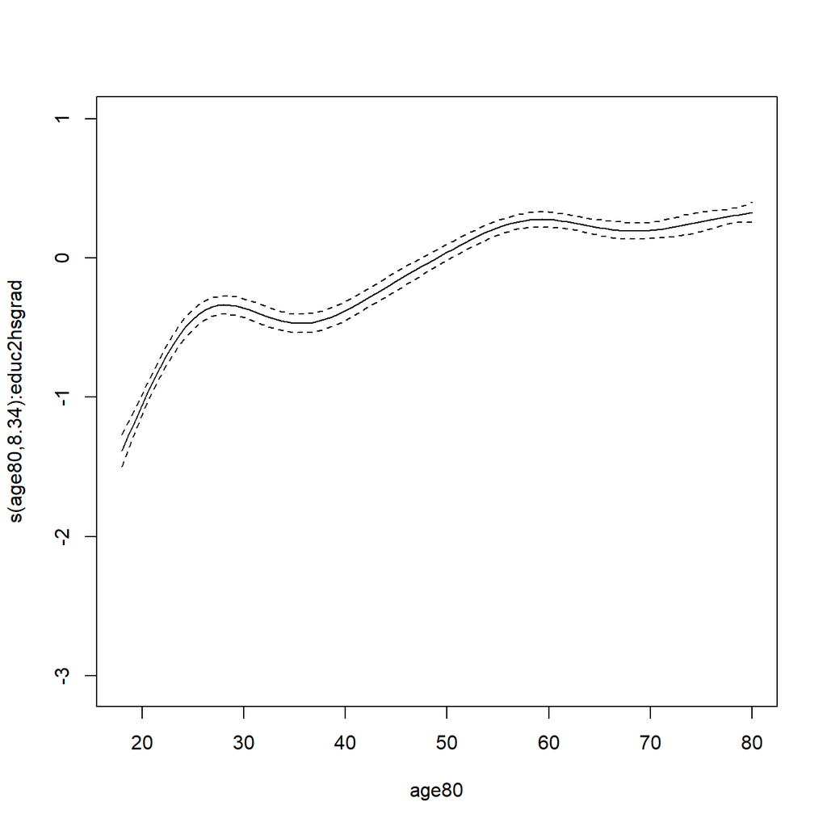

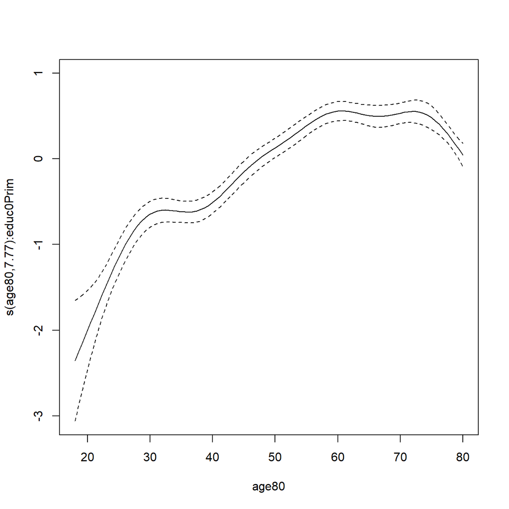

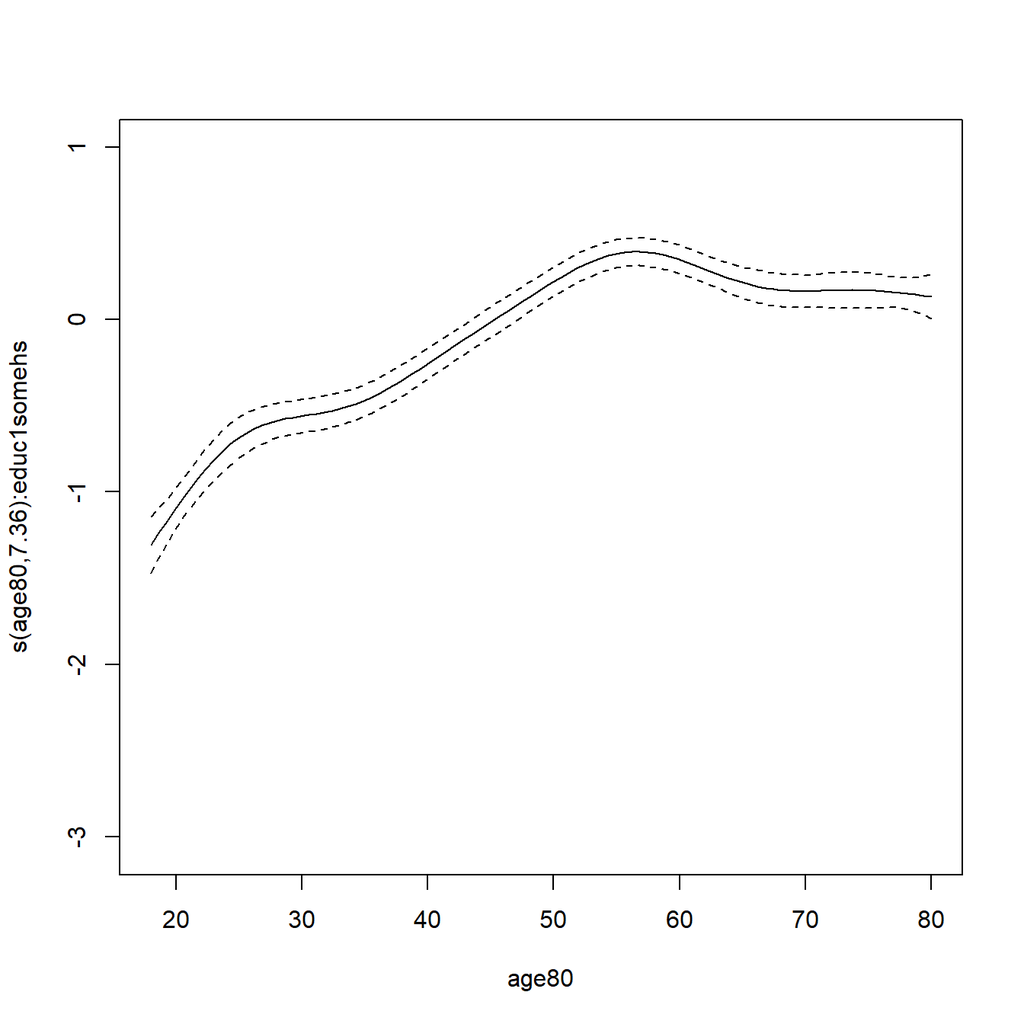

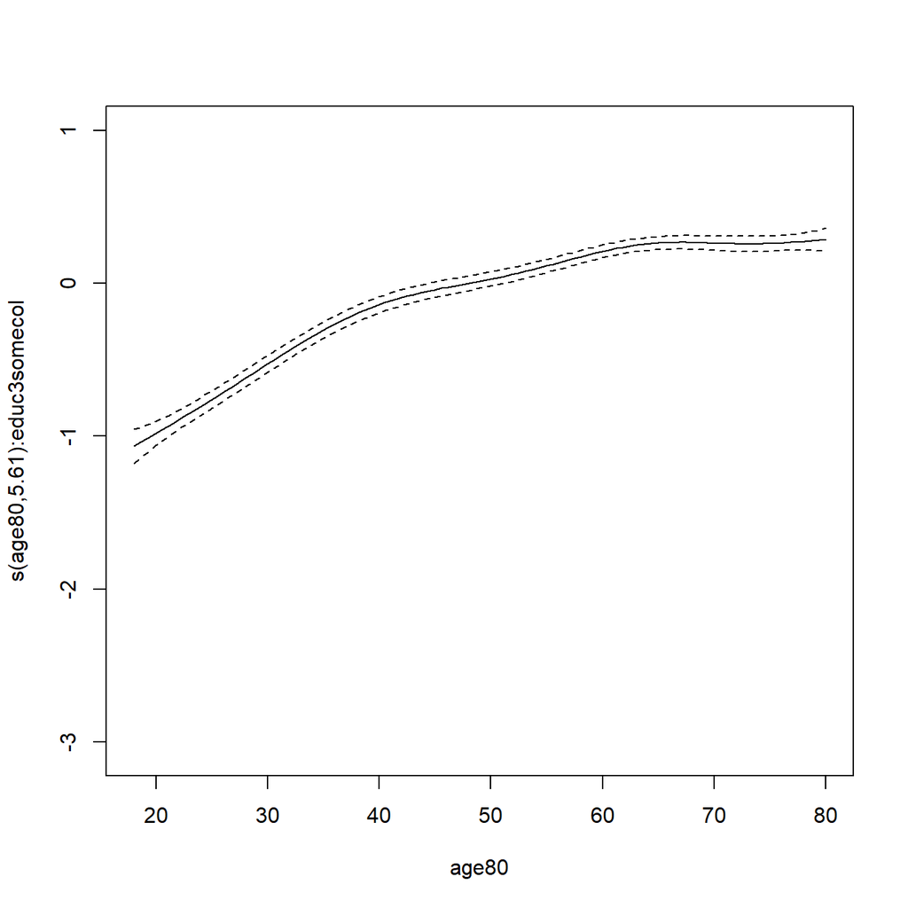

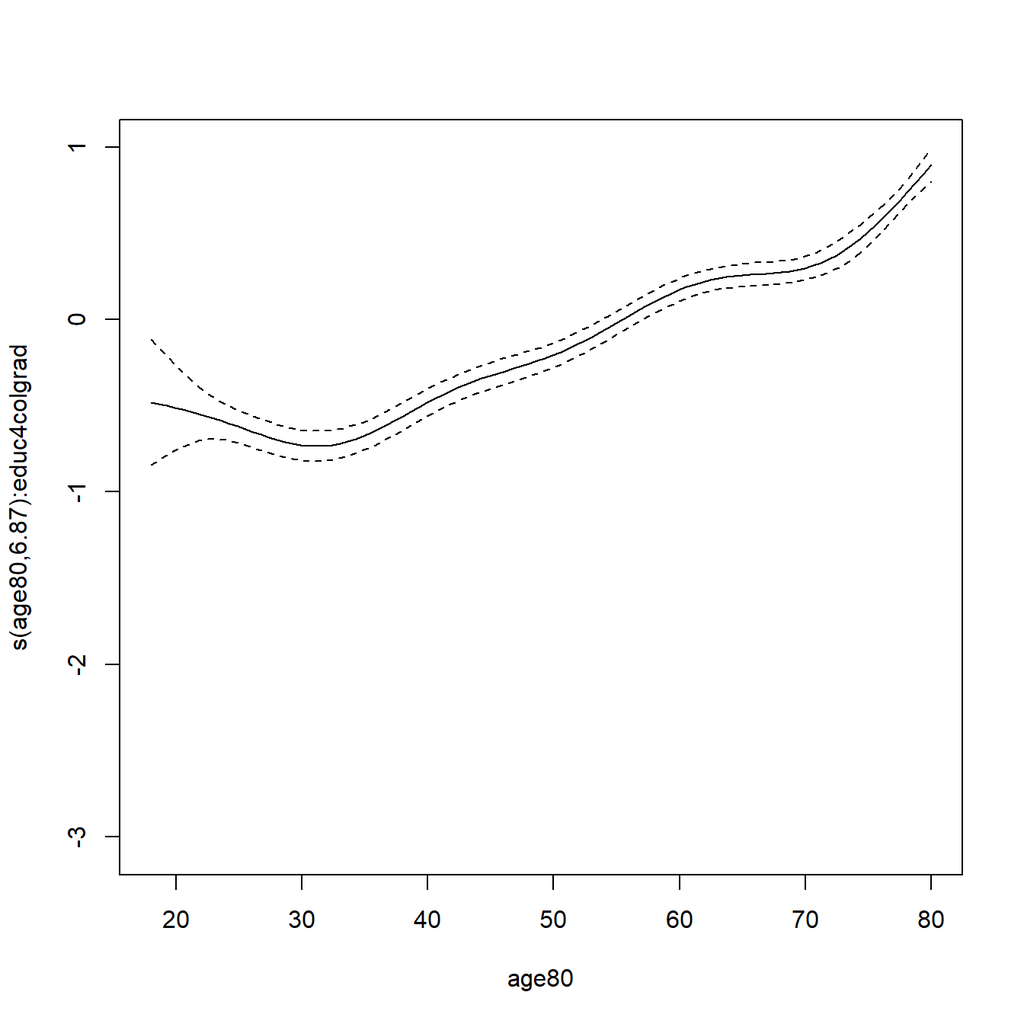

```r
plot(brfgam)
```

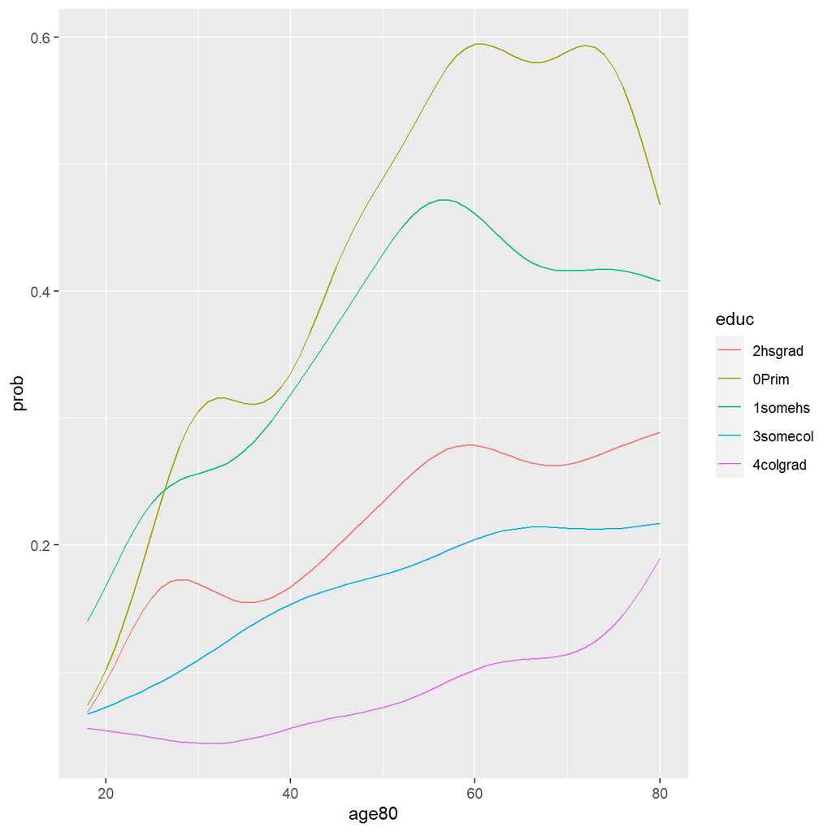

```r
library(emmeans)

rg<-ref_grid(brfgam, at = list(age80 = seq(18, 80)))


marg_logit<-emmeans(object = rg,
                    ~age80+educ,
              type="response" )


 marg_logit%>%
   as.data.frame()%>%
  ggplot()+
  #geom_point(aes(x=paste(msi2, race_eth, sep = "-"), y=rndmean, color=msi2))+
  geom_line(aes(x=age80, y=prob, color=educ, group=educ))
```

Versus the linear terms

```r
brfgam_l<-gam(badhealth~age80+ bmi+ healthmdays+ educ+ male+ black+ hispanic+ other,
              data=brfss_17,
              weights = mmsawt/mean(mmsawt, na.rm=T),
              family=binomial)

summary(brfgam_l)
```

```
##
## Family: binomial
## Link function: logit
##
## Formula:
## badhealth ~ age80 + bmi + healthmdays + educ + male + black +
##     hispanic + other
##
## Parametric coefficients:
##                Estimate Std. Error  z value Pr(>|z|)
## (Intercept)  -5.1312688  0.0414953 -123.659  < 2e-16 ***
## age80         0.0305010  0.0004022   75.830  < 2e-16 ***
## bmi           0.0589483  0.0010116   58.270  < 2e-16 ***
## healthmdays   0.0725197  0.0006864  105.659  < 2e-16 ***
## educ0Prim     0.9177824  0.0287965   31.871  < 2e-16 ***
## educ1somehs   0.6272342  0.0226241   27.724  < 2e-16 ***
## educ3somecol -0.3238136  0.0167605  -19.320  < 2e-16 ***
## educ4colgrad -0.9478952  0.0196263  -48.297  < 2e-16 ***
## male         -0.0446049  0.0133175   -3.349  0.00081 ***
## black         0.3567195  0.0191724   18.606  < 2e-16 ***
## hispanic      0.5482734  0.0184015   29.795  < 2e-16 ***
## other         0.4461126  0.0262150   17.017  < 2e-16 ***
## ---
## Signif. codes:  0 '***' 0.001 '**' 0.01 '*' 0.05 '.' 0.1 ' ' 1
##
##
## R-sq.(adj) =  0.176   Deviance explained = 17.4%
## UBRE = -0.24774  Scale est. = 1         n = 199098
```

### LRT for the difference in model fits

```r
anova( brfgam_l,
       brfgam,
       test="Chisq")
```

|  | Resid. Df | Resid. Dev | Df | Deviance | Pr(>Chi) |
| --- | --- | --- | --- | --- | --- |
| 1 | 199086.0 | 149749.0 | NA | NA | NA |
| 2 | 199052.6 | 164926.6 | 33.40994 | -15177.54 | NA |

### Using smooth terms in other models

The regression splines can also be used in any generalized linear model using functions from the `splines` library.

The `bs()` function is a B-spline basis, and the `ns()` is the natural spline function. The natural splines often behave better at the boundaries of the data.

Here is an example using bmi as a continuous outcome`glm()`

```r
library(survey)
des<-svydesign(ids = ~1,
               stata=~ststr,
               weights = ~ mmsawt,
               data=brfss_17)

ex1<-svyglm(bmi ~ bs(age80)+ male+ black+ hispanic+ other,
    family=gaussian,
    des)

summary(ex1)
```

```
##
## Call:
## svyglm(formula = bmi ~ bs(age80) + male + black + hispanic +
##     other, design = des, family = gaussian)
##
## Survey design:
## svydesign(ids = ~1, stata = ~ststr, weights = ~mmsawt, data = brfss_17)
##
## Coefficients:
##             Estimate Std. Error t value Pr(>|t|)
## (Intercept) 23.93662    0.11044 216.733   <2e-16 ***
## bs(age80)1   6.31008    0.29328  21.516   <2e-16 ***
## bs(age80)2   4.89798    0.18103  27.056   <2e-16 ***
## bs(age80)3   2.39629    0.14074  17.027   <2e-16 ***
## male         0.53440    0.05692   9.389   <2e-16 ***
## black        1.71528    0.09826  17.456   <2e-16 ***
## hispanic     0.81655    0.08820   9.258   <2e-16 ***
## other       -1.81592    0.11032 -16.461   <2e-16 ***
## ---
## Signif. codes:  0 '***' 0.001 '**' 0.01 '*' 0.05 '.' 0.1 ' ' 1
##
## (Dispersion parameter for gaussian family taken to be 34.65587)
##
## Number of Fisher Scoring iterations: 2
```

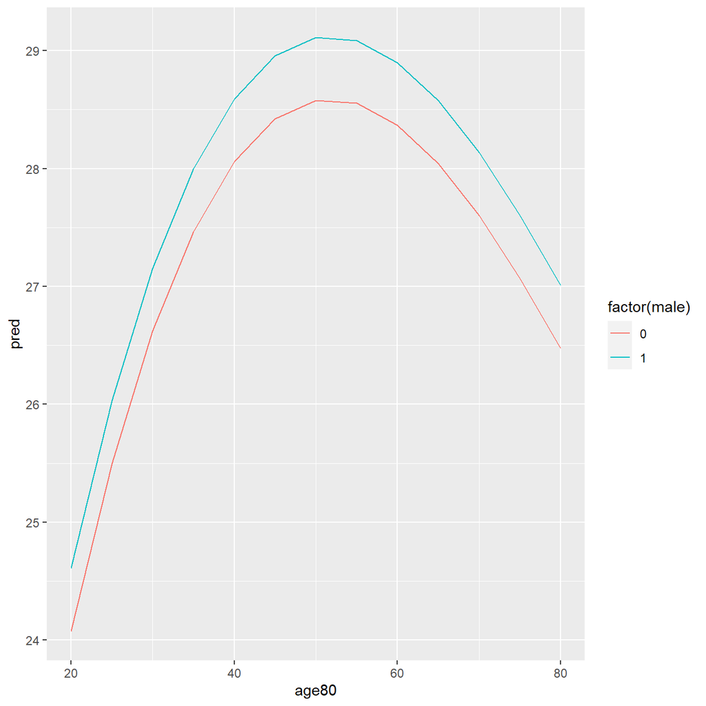

```r
newdat<-expand.grid(age80=seq(20,80,5),
                    male = c(0,1),
                    black = mean(brfss_17$black),
                    hispanic = mean(brfss_17$hispanic),
                    other = mean(brfss_17$other))

newdat$pred<-predict(ex1, newdata=newdat, type="response")

newdat%>%
  ggplot()+
  geom_line(aes(x=age80,
                y=pred,
                color=factor(male) ))
```

```r
ex1<-svyglm(badhealth ~ bs(age80)+ male+ black+ hispanic+ other,
    family=binomial,
    des)
summary(ex1)
```

```
##
## Call:
## svyglm(formula = badhealth ~ bs(age80) + male + black + hispanic +
##     other, design = des, family = binomial)
##
## Survey design:
## svydesign(ids = ~1, stata = ~ststr, weights = ~mmsawt, data = brfss_17)
##
## Coefficients:
##             Estimate Std. Error t value Pr(>|t|)
## (Intercept) -2.72752    0.06845 -39.845  < 2e-16 ***
## bs(age80)1   0.60785    0.16533   3.677 0.000236 ***
## bs(age80)2   1.46671    0.08601  17.053  < 2e-16 ***
## bs(age80)3   1.57588    0.08206  19.203  < 2e-16 ***
## male        -0.13030    0.02650  -4.916 8.82e-07 ***
## black        0.54628    0.03755  14.548  < 2e-16 ***
## hispanic     0.89119    0.03813  23.372  < 2e-16 ***
## other        0.15706    0.06331   2.481 0.013109 *
## ---
## Signif. codes:  0 '***' 0.001 '**' 0.01 '*' 0.05 '.' 0.1 ' ' 1
##
## (Dispersion parameter for binomial family taken to be 1.011092)
##
## Number of Fisher Scoring iterations: 4
```

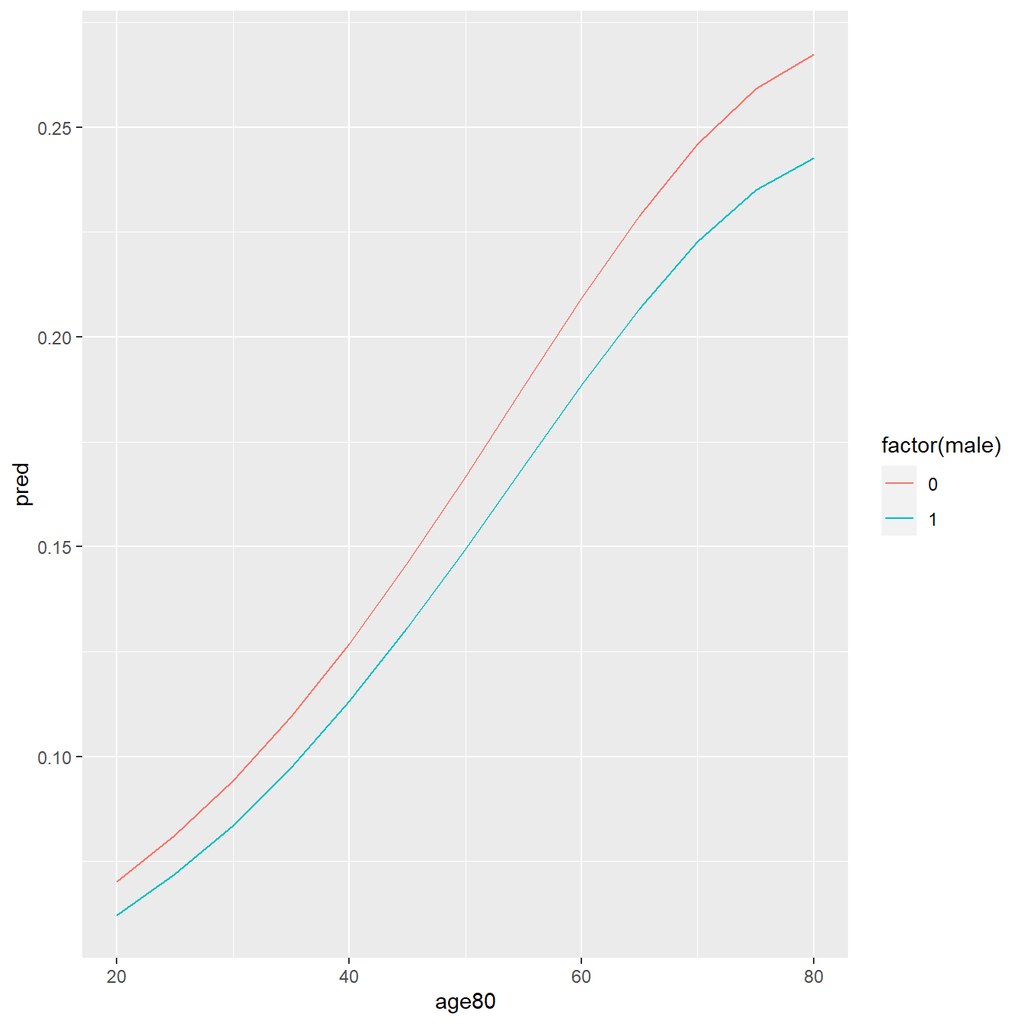

```r
newdat<-expand.grid(age80=seq(20,80,5),
                    male = c(0,1),
                    black = mean(brfss_17$black),
                    hispanic = mean(brfss_17$hispanic),
                    other = mean(brfss_17$other))

newdat$pred<-predict(ex1, newdata=newdat, type="response")

newdat%>%
  ggplot()+
  geom_line(aes(x=age80,
                y=pred,
                color=factor(male) ))
```